# Projekt z zakresu analizy danych

HR employee analysis

Autor

Piotr Szyszka

# Słowem wstępu

Raport jest wynikiem pracy włożonej w projekt na przedmiot *Projekt z zakresu analizy danych.*

# Cel

Głównym celem projektu jest przeprowadzenie szeroko rozumianej analizy na badanym zbiorze danych.  
Dzieki niej odkryta zostanie struktura wewnętrznych zależności zbioru wraz z charakterystyką wchodzących cech.  
Dodatkowo dokładnie zostanie zbadany problem występowania wypalenia zawodowego poprzez zbudowanie, ocenę i porównanie modeli służących klasyfikacji.

# Opis zbioru badawczego

Dane zostały pobrane z [kaggle](https://www.kaggle.com/datasets/whenamancodes/hr-employee-attrition).  
Zbiór przedstawia fikcyjne dane dotyczące zatrudnionych pracowników w pewnej firmie.  
Cały zbiór danych składa się ze 35 kolumn oraz 1470 wierszy, przy czym część z dostępnych cech uznaliśmy za nieistotne pod kątem przeprowadzanej analizy. Dlatego spośród 35 wybraliśmy 21. Są to:

- `Age` - wiek pracownika,
- `Attrition` - zmienna kategoryczna odpowiadająca za wypalenie zawodowe (1 - wystąpiło, 0 - nie wystąpiło),
- `BusinessTravel` - częstotliwość podróżowania w sprawach biznesowych,
- `Department` - wydział organizacji,
- `DistanceFromHome` - odległośc od pracy,
- `Education` - poziom wykształcenia,
- `EnvironmentSatisfaction` - zadowolenie z otoczenia pracy,
- `Gender` - płeć,
- `JobInvolvement` - zaangażowanie w pracę,
- `JobSatisfaction` - satysfakcja z pracy,
- `MaritalStatus` - stan cywilny,
- `MonthlyIncome` - miesięczny przychód,
- `MonthlyRate` - stawka miesięczna,
- `NumCompaniesWorked` - ilość poprzednich firm,
- `OverTime` - zmienna kategoryczna odpowiadająca za wykonywanie nadgodzin (1 - występiły, 0 - nie wystąpiły),
- `PercentSalaryHike` - podwyżka w %,
- `RelationshipSatisfaction` - satysfakcja z relacji prywatnych,
- `TotalWorkingYears` - ilość przepracowanych lat,
- `TrainingTimesLastYear` - liczba szkoleń w poprzednim roku,
- `WorkLifeBalance` - balans między karierą, a życiem prywatnym,
- `YearsAtCompany` - staż w organizacji (w latach).

przedstawienie

| Age | Attrition | BusinessTravel | Department | DistanceFromHome | Education | EnvironmentSatisfaction | Gender | JobInvolvement | JobSatisfaction | MaritalStatus | MonthlyIncome | MonthlyRate | NumCompaniesWorked | OverTime | PercentSalaryHike | RelationshipSatisfaction | TotalWorkingYears | TrainingTimesLastYear | WorkLifeBalance | YearsAtCompany |
| --- | --- | --- | --- | --- | --- | --- | --- | --- | --- | --- | --- | --- | --- | --- | --- | --- | --- | --- | --- | --- |
| 30 | No | Travel Rarely | Research & Development | 8 | 2 | 2 | Female | 4 | 1 | Married | 11,416 | 17,802 | 0 | Yes | 12 | 3 | 9 | 4 | 2 | 8 |
| 53 | No | Travel Rarely | Research & Development | 5 | 3 | 3 | Female | 3 | 3 | Divorced | 19,094 | 10,735 | 4 | No | 11 | 4 | 26 | 3 | 2 | 14 |
| 35 | No | Travel Rarely | Research & Development | 16 | 3 | 1 | Male | 4 | 2 | Married | 2,426 | 16,479 | 0 | No | 13 | 3 | 6 | 5 | 3 | 5 |
| 56 | No | Travel Rarely | Research & Development | 23 | 3 | 4 | Male | 3 | 2 | Married | 13,402 | 18,235 | 4 | Yes | 12 | 1 | 33 | 0 | 3 | 19 |
| 28 | Yes | Travel Rarely | Research & Development | 24 | 3 | 3 | Male | 2 | 3 | Single | 2,028 | 12,947 | 5 | Yes | 14 | 2 | 6 | 4 | 3 | 4 |
| 36 | No | Non Travel | Research & Development | 9 | 4 | 1 | Male | 4 | 2 | Married | 2,810 | 9,238 | 1 | No | 22 | 2 | 5 | 3 | 3 | 5 |
| 42 | Yes | Travel Frequently | Sales | 12 | 3 | 3 | Male | 3 | 1 | Single | 13,758 | 2,447 | 0 | Yes | 12 | 2 | 22 | 2 | 2 | 21 |
| 23 | Yes | Travel Rarely | Research & Development | 6 | 3 | 3 | Male | 4 | 1 | Married | 1,601 | 3,445 | 1 | Yes | 21 | 3 | 1 | 2 | 3 | 0 |
| 31 | No | Travel Frequently | Sales | 7 | 4 | 1 | Female | 3 | 1 | Married | 9,637 | 8,277 | 2 | No | 14 | 4 | 9 | 3 | 3 | 3 |
| 48 | No | Travel Rarely | Research & Development | 4 | 4 | 3 | Male | 2 | 3 | Single | 10,999 | 22,245 | 7 | No | 14 | 2 | 27 | 3 | 3 | 15 |
| 39 | No | Non Travel | Sales | 21 | 4 | 1 | Female | 1 | 3 | Married | 5,736 | 3,987 | 6 | No | 19 | 3 | 10 | 1 | 3 | 3 |
| 47 | No | Travel Rarely | Research & Development | 2 | 2 | 3 | Female | 3 | 4 | Married | 16,752 | 12,982 | 1 | Yes | 11 | 3 | 26 | 3 | 2 | 26 |
| 26 | Yes | Non Travel | Sales | 29 | 2 | 2 | Male | 1 | 1 | Single | 4,969 | 21,813 | 8 | No | 18 | 4 | 7 | 6 | 3 | 2 |
| 36 | No | Travel Rarely | Sales | 2 | 2 | 2 | Male | 2 | 3 | Married | 7,596 | 3,809 | 1 | No | 13 | 2 | 10 | 2 | 3 | 10 |
| 28 | No | Travel Rarely | Sales | 5 | 3 | 4 | Male | 3 | 1 | Single | 8,463 | 23,490 | 0 | No | 18 | 4 | 6 | 4 | 3 | 5 |
| 27 | No | Travel Frequently | Research & Development | 1 | 1 | 3 | Male | 2 | 1 | Married | 4,298 | 9,679 | 5 | No | 19 | 3 | 6 | 1 | 3 | 2 |
| 33 | No | Travel Frequently | Sales | 7 | 3 | 4 | Male | 3 | 1 | Married | 4,373 | 17,456 | 0 | No | 14 | 1 | 5 | 2 | 3 | 4 |
| 19 | Yes | Travel Frequently | Sales | 1 | 1 | 3 | Female | 1 | 1 | Single | 2,325 | 20,989 | 0 | No | 21 | 1 | 1 | 5 | 4 | 0 |
| 50 | No | Travel Frequently | Research & Development | 1 | 3 | 1 | Female | 3 | 2 | Married | 18,172 | 9,755 | 3 | Yes | 19 | 1 | 28 | 1 | 2 | 8 |
| 38 | No | Non Travel | Sales | 10 | 3 | 3 | Female | 3 | 4 | Single | 5,666 | 19,899 | 1 | Yes | 13 | 2 | 6 | 1 | 3 | 5 |

losowe 20. obiektów z naszego zbioru danych

# Przegląd zmiennych

W tej części przedstawimy strukturę zbioru. Omówione zostaną podstawowe statystyki opisowe dla zmiennych numerycznych wraz ze scharakteryzowaniem cech typu jakościowego.

## Zmienne numeryczne

### Statystyki opisowe

**Dane**

| Age | DistanceFromHome | MonthlyIncome | MonthlyRate | NumCompaniesWorked | PercentSalaryHike | TotalWorkingYears | TrainingTimesLastYear | YearsAtCompany |
| --- | --- | --- | --- | --- | --- | --- | --- | --- |
| 41 | 1 | 5993 | 19479 | 8 | 11 | 8 | 0 | 6 |
| 49 | 8 | 5130 | 24907 | 1 | 23 | 10 | 3 | 10 |
| 37 | 2 | 2090 | 2396 | 6 | 15 | 7 | 3 | 0 |
| 33 | 3 | 2909 | 23159 | 1 | 11 | 8 | 3 | 8 |
| 27 | 2 | 3468 | 16632 | 9 | 12 | 6 | 3 | 2 |
| 32 | 2 | 3068 | 11864 | 0 | 13 | 8 | 2 | 7 |
| 59 | 3 | 2670 | 9964 | 4 | 20 | 12 | 3 | 1 |
| 30 | 24 | 2693 | 13335 | 1 | 22 | 1 | 2 | 1 |
| 38 | 23 | 9526 | 8787 | 0 | 21 | 10 | 2 | 9 |
| 36 | 27 | 5237 | 16577 | 6 | 13 | 17 | 3 | 7 |

**Statystyki**

|  | Age | DistanceFromHome | MonthlyIncome | MonthlyRate | NumCompaniesWorked | PercentSalaryHike | TotalWorkingYears | TrainingTimesLastYear | YearsAtCompany |
| --- | --- | --- | --- | --- | --- | --- | --- | --- | --- |
| Min. | 18.00 | 1.00 | 1009.00 | 2094.00 | 0.00 | 11.00 | 0.00 | 0.00 | 0.00 |
| 1st Qu. | 30.00 | 2.00 | 2911.00 | 8047.00 | 1.00 | 12.00 | 6.00 | 2.00 | 3.00 |
| Median | 36.00 | 7.00 | 4919.00 | 14235.50 | 2.00 | 14.00 | 10.00 | 3.00 | 5.00 |
| Mean | 36.92 | 9.19 | 6502.93 | 14313.10 | 2.69 | 15.21 | 11.28 | 2.80 | 7.01 |
| 3rd Qu. | 43.00 | 14.00 | 8379.00 | 20461.50 | 4.00 | 18.00 | 15.00 | 3.00 | 9.00 |
| Max. | 60.00 | 29.00 | 19999.00 | 26999.00 | 9.00 | 25.00 | 40.00 | 6.00 | 40.00 |
| St.dev | 13.97 | 10.30 | 6746.44 | 8801.13 | 3.19 | 5.11 | 13.86 | 1.94 | 14.71 |

Z powyższego zestawienia dowiadujemy się, że:

- pracownicy byli w wieku od 18. do 60. lat;
- średnia przychodów wynosi nieco ponad 6500;
- badani średnio przepracowali 11.28 lat.

### Korelacje

Struktura zależności liniowej przedstawiona zostanie w postaci macierzy korelacji.

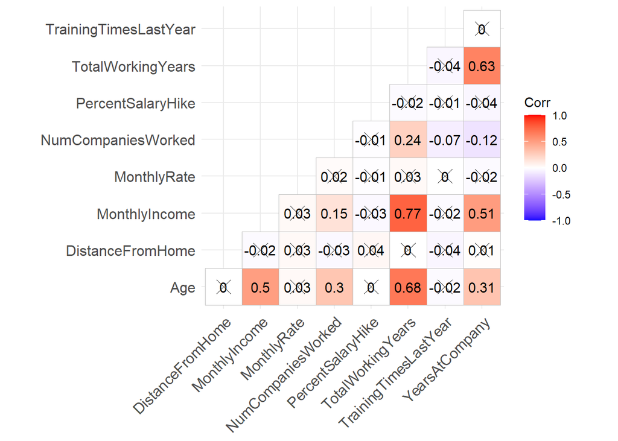

Z powyższego zestawienia widzimy, że najbardziej skorelowane są zmienne `MonthlyIncome` z `TotalWorkingYears` ($\rho = 0.77$).

Następnie `TotalWorkingYears` z `Age` ($\rho = 0.68$).

Zauważmy jeszcze, że `TotalWorkingYears` koreluje z `YearsAtCompany` na poziomie $\rho = 0.63$.

Pozostałe zmienne nie wykazują silnych korelacji między sobą.

### Rozkłady

Dzieki wizualizacji rozkładów zmiennych możemy wstępnie zorientować się o charakterze zjawiska.

**Age**

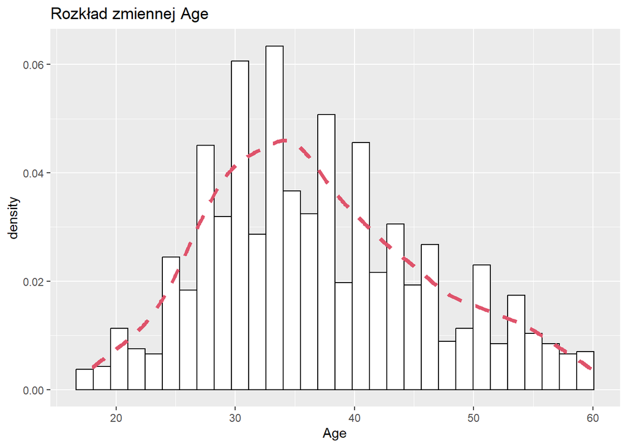

**MonthlyIncome**

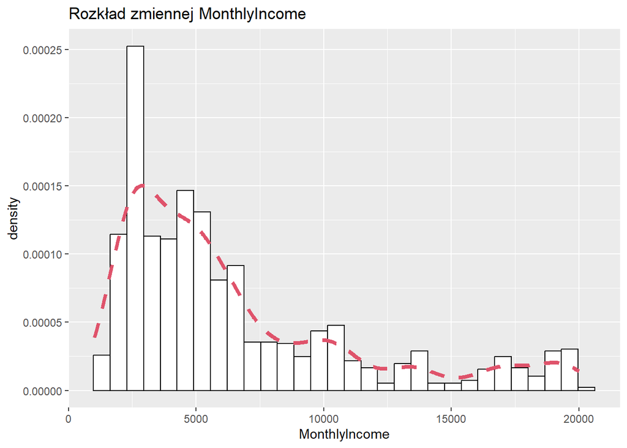

**MonthlyRate**

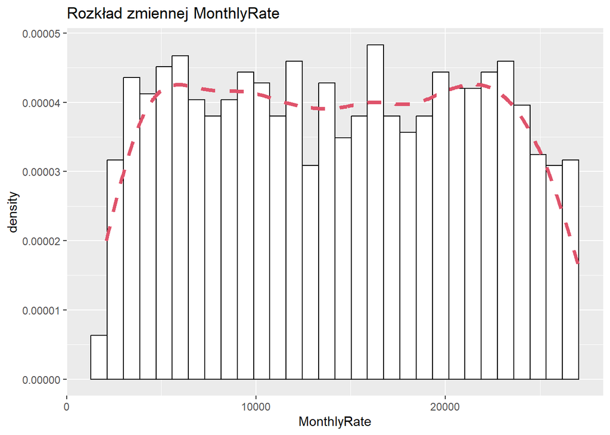

**DistanceFromHome**

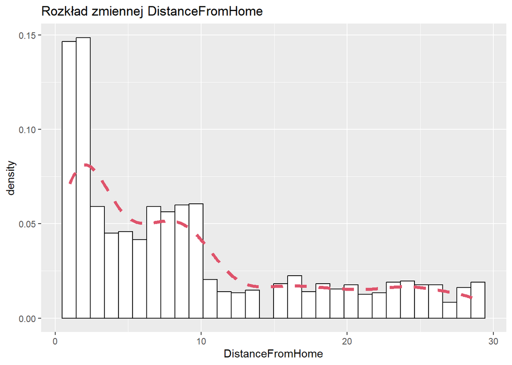

### Zmienności w zarobkach

Zbadajmy jaka jest struktura zarobków w naszym zbiorze. O tym mówią nam dwie zmienne - `MonthlyRate` będąca stawką miesieczną danego pracownika oraz `MonthlyIcome`, czyli przychód (po podatkach).

Zmienność najłatwiej jest ocenić na podstawie wykresu ramka-wąsy.

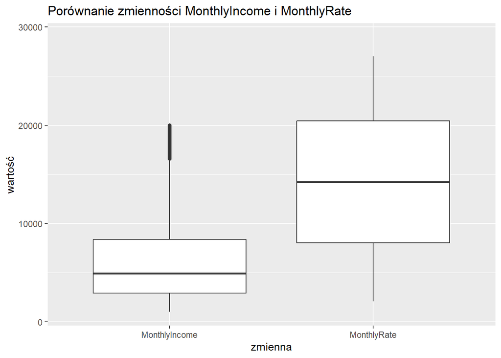

## Zmienne kategoryczne

W badanym zbiorze mamy kilka zmiennych kategorycznych (typu factor). Są to:

- `Attrition`,
- `Department`,
- `Education`,
- `EnvironmentSatisfaction`,
- `Gender`,
- `JobInvolment`,
- `JobSatisfaction`,
- `MaritalStatus`,
- `OverTime`.
- `RelationShipSatisfaction`,
- `WorkLifeBalance`.

### Podział

Zbadajmy w jakich proporcjach występują poszczególne poziomy nasze zmienne kategoryczne.

Wybierz typ wykresu oraz zmienną, dla której ma zostać narysowany.

Typ wykresu

Zmienna

[interactive chart not shown]

### Niezależność z Attrition

Zbadanie niezależności cech pozwoli na wskazanie tych czynników, które współwystępują nieprzypadkowo z wypaleniem zawodowym.

|  | p | statystka | Wniosek |
| --- | --- | --- | --- |
| Department | 0.005 | 10.80 | Nieniezależne |
| Education | 0.546 | 3.07 | Niezależne |
| EnvironmentSatisfaction | 0.000 | 22.50 | Nieniezależne |
| Gender | 0.291 | 1.12 | Niezależne |
| JobInvolvement | 0.000 | 28.49 | Nieniezależne |
| JobSatisfaction | 0.001 | 17.51 | Nieniezależne |
| MaritalStatus | 0.000 | 46.16 | Nieniezależne |
| OverTime | 0.000 | 87.56 | Nieniezależne |
| RelationshipSatisfaction | 0.155 | 5.24 | Niezależne |
| WorkLifeBalance | 0.001 | 16.33 | Nieniezależne |

Z powyższego zestawienia dowiadujemy się, że zmienne które mają istotny związek z wystąpieniem wypalenia zawodowego to *Department, EnvironmentSatisfaction, JobInvolvement, JobSatisfaction, MaritalStatus, OverTime, WorkLifeBalance*.

# Hipotezy

## Średnie dochody w podziale na płeć

Na początku przyjrzyjmy się samemu zjawisku

| Female | Female Gender | Female MonthlyIncome |
| --- | --- | --- |
|  | Female:588 | Min. : 1129 |
|  | Male : 0 | 1st Qu.: 3037 |
|  |  | Median : 5082 |
|  |  | Mean : 6687 |
|  |  | 3rd Qu.: 8712 |
|  |  | Sd: 4696 |

| Male | Male Gender | Male MonthlyIncome |
| --- | --- | --- |
|  | Female: 0 | Min. : 1009 |
|  | Male :882 | 1st Qu.: 2820 |
|  |  | Median : 4838 |
|  |  | Mean : 6381 |
|  |  | 3rd Qu.: 8114 |
|  |  | Sd: 4715 |

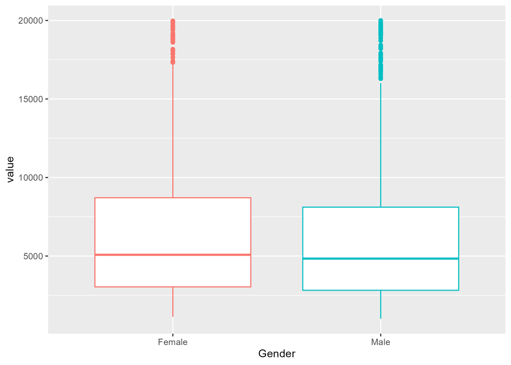

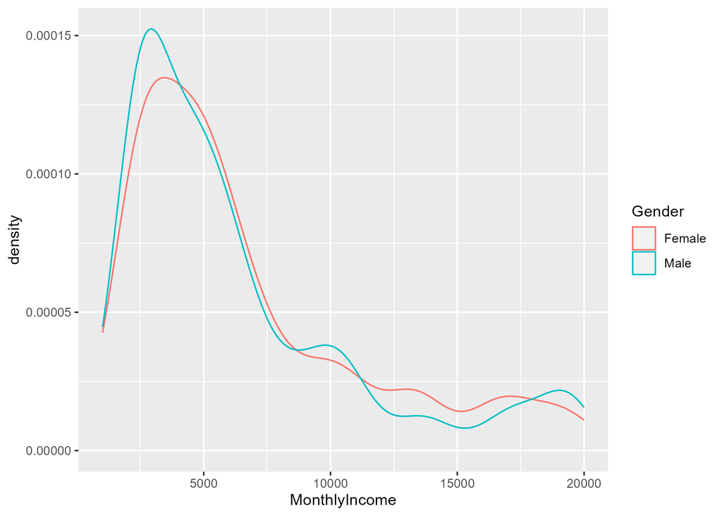

Przy pomocy testu t-studenta dla prób niezależnych, na poziomie istotności $1-\alpha = 0.95$ zweryfikujemy hipotezę, że *średnia wartość dochodu w podziale na płeć jest równa, wobec hipotezy, że są różne.*

**Ważne**

Statystyka testowa bazuje na średnich arytmetycznych, a na mocy *Centralnego Twierdzenia Granicznego* wiemy, że ich rozkłady dążą do rozkładu normalnego. W konsekwencji, pomimo niezgodnośći z rozkładem normalnym samej cechy, statystyka testowa, wraz z liczebnością próby, również będzie dążyć do rozkładu Gaussa.  
Stąd stosowanie testu t-studenta w tak licznych próbach jest uzasadnione. [Źródło](https://thestatsgeek.com/2013/09/28/the-t-test-and-robustness-to-non-normality/)

$$H_0: \mu_0 = \mu_1$$

$$H_1: \mu_0 \neq \mu_1$$

Zakładamy, że wariancje w obu populacjach są równe.

```r
t.test(fem_mi$MonthlyIncome, ma_mi$MonthlyIncome, var.equal = TRUE)
```

```
    Two Sample t-test

data:  fem_mi$MonthlyIncome and ma_mi$MonthlyIncome
t = 1.2213, df = 1468, p-value = 0.2222
alternative hypothesis: true difference in means is not equal to 0
95 percent confidence interval:
 -185.5303  797.6470
sample estimates:
mean of x mean of y
 6686.566  6380.508
```

Wniosek - **brak podstaw do odrzucenia hipotezy zerowej (o równości dochodów w podziale na płeć).**

## Przychody w zalezności od wykształcenia

Zastanawiające może być czy istnieje róznica w poziomie zarobków (w kontekście średniej) w zależności od wykształcenia.

Przyjrzyjmy się więc hipotezie

$$H_0: \forall_{1 \leq i \leq 5 } \mu_i = \mu$$
gdzie $\mu_i$ oznacza średnią w i-tej grupie wyznaczoną przez dany poziom edukacji.

|  | 1 | 2 | 3 | 4 | 5 |
| --- | --- | --- | --- | --- | --- |
| n | 170 | 282 | 572 | 398 | 48 |
| mean | 5640.571 | 6226.645 | 6517.264 | 6832.402 | 8277.646 |
| sd | 4484.500 | 4524.684 | 4817.403 | 4657.191 | 5061.430 |
| Q1 | 2693.00 | 3067.25 | 2759.75 | 3482.75 | 4731.25 |
| Q2 | 3849.0 | 4891.5 | 4762.0 | 5341.5 | 6203.0 |
| Q3 | 7170.25 | 6840.00 | 8808.00 | 8726.50 | 11731.50 |

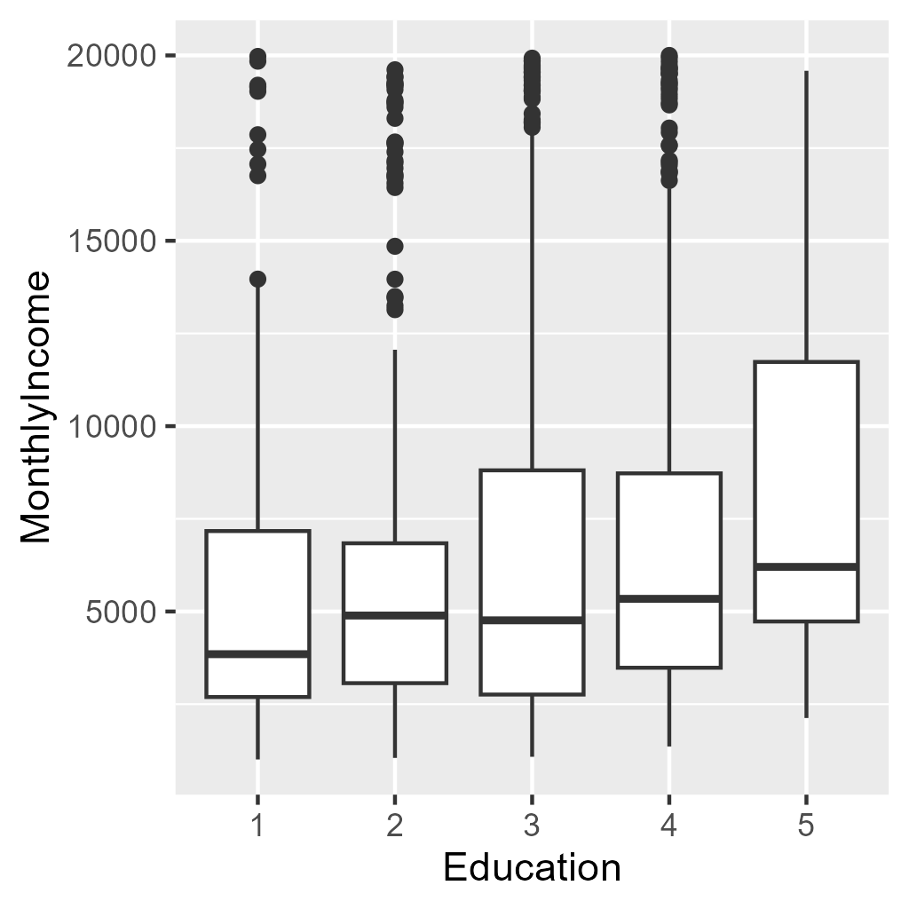

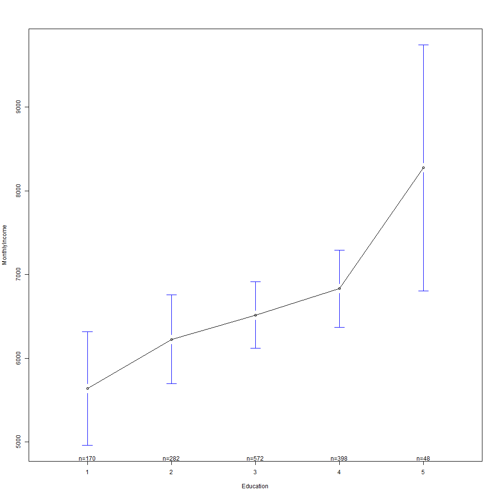

Sprawdźmy czy założenie o zgodności z rozkładem normalnym w podgrupach jest spełnione.

| Education | statistic | p.value |
| --- | --- | --- |
| 1 | 0.7793141 | 0.0000000 |
| 2 | 0.7884888 | 0.0000000 |
| 3 | 0.8373571 | 0.0000000 |
| 4 | 0.8315183 | 0.0000000 |
| 5 | 0.8726231 | 0.0000919 |

Okazuje się, że cecha w żadnej z podgrup nie ma rozkładu normalnego.

Przyjmując jednak, że są to grupy dużo liczebne, poruszone zostało m.in w pracy Lindmana 1974 i Boxa i Andersena 1955, że test Omnibus ANOVA jest odporny na brak normalności rozkładu.

Zbadajmy czy grupy są jednorodne w sensie wariancji.

```
Levene's Test for Homogeneity of Variance (center = median)
        Df F value Pr(>F)
group    4  1.6979  0.148
      1465
```

Okazuje się, że tak. Przejdźmy więc do testu *ANOVA*

```
              Df      Sum Sq  Mean Sq F value  Pr(>F)
Education      4   342451522 85612881   3.893 0.00377 **
Residuals   1465 32217723516 21991620
---
Signif. codes:  0 '***' 0.001 '**' 0.01 '*' 0.05 '.' 0.1 ' ' 1
```

Okazuje się, że efekt rzeczywiście jest istotny.

### Post hoc

#### Test LSD Fisher’a

```
    Pairwise comparisons using t tests with pooled SD

data:  df$MonthlyIncome and df$Education

  1     2     3     4
2 0.595 -     -     -
3 0.195 0.607 -     -
4 0.046 0.389 0.607 -
5 0.006 0.046 0.088 0.219

P value adjustment method: holm
```

#### Test Scheffe

| MonthlyIncome | groups |
| --- | --- |
| 8,277.646 | a |
| 6,832.402 | ab |
| 6,517.264 | ab |
| 6,226.645 | ab |
| 5,640.571 | b |

Testy *Scheffe* i *LSD* wskazują na istotną różnicę w dochodach między poziomami wykształcenia.

# Algorytmy klasyfikujące

W tej części prezentacji zbudowane i scharakteryzowane zostaną modele slużące klasyfikacji i predykcji dla zmiennej `Atrition` (wypalenie zawodowe).

## Analiza dyskryminacyjna

Analiza funkcji dyskryminacyjnych pozwoli nam rozstrzygnąć, które ze zmiennych charakteryzują się największą różnicą ze względu na średnią. Pozwoli nam to więc znaleźć te czynniki, w sensie których występują największe różnice w obu grupach. Poprowadzona zostanie ona na zmiennych typu numerycznego.

### Założenia

Analiza dyskryminacyjna zakłada, że:

- cechy mają w grupach wielowymiarowy rozkład normalny,
- macierze kowariancji w grupach są homogeniczne,
- brak współliniowości zmiennych objaśniających,
- brak wartości odstających.

Okazuje się, że badany zbiór danych *nie spełnia założenia o wielowymiarowym rozkładzie normalnym* cech objaśniających `Attrition`.  
Mając na uwadze fakt, że moc każdego testu rośnie wraz z liczebnością próby oraz sam jej rozmiar (**1470 obserwacji**), usprawiedliwia nam niespełnienie tego założenia.  
Dodatkowo analiza dyskryminacyjna, dla której większym zagrożeniem jest niejednorodność macierzy kowariancji w grupach, jest odporna na nienormalność.

Co do współliniowości - w naszym zbiorze *żadna ze zmiennych nie jest współiniowa z inną.* Patrz tu

Dane po przekształceniu prezentują się następująco:

**Przed**

| Attrition | Age | DistanceFromHome | MonthlyIncome | MonthlyRate | NumCompaniesWorked | PercentSalaryHike | TotalWorkingYears | TrainingTimesLastYear | YearsAtCompany |
| --- | --- | --- | --- | --- | --- | --- | --- | --- | --- |
| Yes | 41 | 1 | 5993 | 19479 | 8 | 11 | 8 | 0 | 6 |
| No | 49 | 8 | 5130 | 24907 | 1 | 23 | 10 | 3 | 10 |
| Yes | 37 | 2 | 2090 | 2396 | 6 | 15 | 7 | 3 | 0 |
| No | 33 | 3 | 2909 | 23159 | 1 | 11 | 8 | 3 | 8 |
| No | 27 | 2 | 3468 | 16632 | 9 | 12 | 6 | 3 | 2 |
| No | 32 | 2 | 3068 | 11864 | 0 | 13 | 8 | 2 | 7 |
| No | 59 | 3 | 2670 | 9964 | 4 | 20 | 12 | 3 | 1 |
| No | 30 | 24 | 2693 | 13335 | 1 | 22 | 1 | 2 | 1 |
| No | 38 | 23 | 9526 | 8787 | 0 | 21 | 10 | 2 | 9 |
| No | 36 | 27 | 5237 | 16577 | 6 | 13 | 17 | 3 | 7 |

**Po**

| Attrition | Age | DistanceFromHome | MonthlyIncome | MonthlyRate | NumCompaniesWorked | PercentSalaryHike | TotalWorkingYears | TrainingTimesLastYear | YearsAtCompany |
| --- | --- | --- | --- | --- | --- | --- | --- | --- | --- |
| Yes | 4.532 | 0.693 | 5.810 | 1436.093 | 1.973 | 0.651 | 2.928 | 0.000 | 2.379 |
| No | 4.788 | 2.197 | 5.744 | 1705.987 | 0.670 | 0.661 | 3.285 | 2.162 | 3.077 |
| Yes | 4.387 | 1.099 | 5.345 | 330.213 | 1.768 | 0.656 | 2.727 | 2.162 | 0.000 |
| No | 4.228 | 1.386 | 5.496 | 1621.199 | 0.670 | 0.651 | 2.928 | 2.162 | 2.759 |
| No | 3.955 | 1.099 | 5.574 | 1285.580 | 2.057 | 0.652 | 2.506 | 2.162 | 1.229 |
| No | 4.186 | 1.099 | 5.520 | 1014.561 | 0.000 | 0.654 | 2.928 | 1.555 | 2.579 |
| No | 5.060 | 1.386 | 5.457 | 897.730 | 1.487 | 0.660 | 3.595 | 2.162 | 0.743 |
| No | 4.097 | 3.219 | 5.461 | 1101.176 | 0.670 | 0.661 | 0.757 | 1.555 | 0.743 |
| No | 4.425 | 3.178 | 6.000 | 821.998 | 0.000 | 0.660 | 3.285 | 1.555 | 2.924 |
| No | 4.349 | 3.332 | 5.753 | 1282.599 | 1.768 | 0.654 | 4.239 | 2.162 | 2.579 |

<sup>a</sup> p-value z testu M-Boxa: 0.052000

Po usunięciu obserwacji odstających, zdiagnozowanych za pomocą odległości *Mahalanobis’a*, budowa modelu jest uzasadniona.

### Model analizy dyskryminacyjnej

Cały zestaw danych podzielony został na zbiór uczący i testowy w proporcji $\frac{2}{3} : \frac{1}{3}$. Prawdopodobieństwa przynależości do grupy są w proporcji 0.7:0.3.

### Wagi funkcji dyskryminacyjnych

Zmienna zależna ma tylko dwa poziomy, wobec tego powstała tylko jedna funkcja dyskryminacyjna `LD1`. W celu łatwiejszej interpretacji i ujednolicenia rzędu wielkości, model został zbudowany na danych zestandaryzowanych.

|  | LD1 |
| --- | --- |
| Age | -0.2961025 |
| DistanceFromHome | 0.3849750 |
| MonthlyIncome | -0.2733512 |
| MonthlyRate | 0.0630272 |
| NumCompaniesWorked | 0.4021798 |
| PercentSalaryHike | -0.0858485 |
| TotalWorkingYears | -0.3365796 |
| TrainingTimesLastYear | -0.1859740 |
| YearsAtCompany | -0.2483784 |

Największy wkład w `LD1` ma `NumCompaniesWorked`, czyli ilość firm, w których pracował badany.

### Średnie grupowe

Przy pomocy analizy średnich grupowych jesteśmy w stanie wskazać te czynniki, które najbardziej różnicują dwie grupy co do średniej.

|  | No | Yes |
| --- | --- | --- |
| prior: | 0.7 | 0.3 |
| Age | 0.065637188 | -0.34147955 |
| DistanceFromHome | -0.042022051 | 0.21862105 |
| MonthlyIncome | 0.077310465 | -0.40221014 |
| MonthlyRate | -0.009119666 | 0.04744535 |
| NumCompaniesWorked | -0.022001613 | 0.11446409 |
| PercentSalaryHike | 0.006201656 | -0.03226431 |
| TotalWorkingYears | 0.083438088 | -0.43408929 |
| TrainingTimesLastYear | 0.021329507 | -0.11096744 |
| YearsAtCompany | 0.080733282 | -0.42001745 |

### Predykcja

W tej części to co najciekawsze - zbadamy jak celnie nasz model przyporządkowuje obiekty do poszczególnych grup. Sprawdźmy jak radzi sobie ze zbiorem testowym.

| LDA | LDA Obs No | LDA Obs Yes |
| --- | --- | --- |
| Pred |  |  |
| No | 384 | 57 |
| Yes | 27 | 22 |

celność: 83%

## KNN

KNN Metoda K Najbliższych Sąsiadów to algorytm regresji nieparametrycznej, należy do grupy algorytmów leniwych. Oznacza to, algorytm nie zakłada z góry, iż mamy do czynienia z pewnym rozkładem danych oraz że nie buduje modelu w fazie uczenia, lecz dopiero gdy model zostanie zapytany o wynik predykcji. Użyliśmy go w celu klasyfikacji danego pracownika do grupy, w której znajdują się wypalone zawodowo osoby lub do grupy osób nie charakteryzujących się tą cechą. Klayfikacja jest oparta o znalezienie najbliższej okolicy nowej danej (bazującej na odległości Euklidesowej) i porównanie jej do k-sąsiadów.

### Model

Model zbudowany został za pomocą funkcji `knn()` z pakietu `class`. Do modelu włączone zostaną wszystkie zmienne numeryczne. Aby wybrać odpowiednie *k*, które jest parametrem liczby sąsiadów tej metody, przygotowaliśmy funckję, która wyznaczy najlepsze k względem najtrafniejszej predykcji.

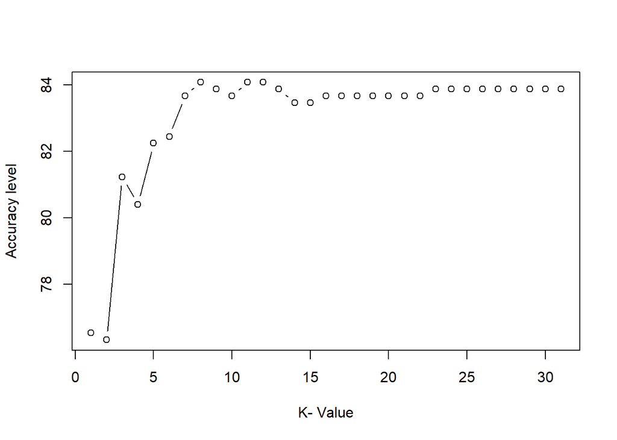

### Predykcja

| KNN | KNN Obs No | KNN Obs Yes |
| --- | --- | --- |
| Pred |  |  |
| No | 405 | 75 |
| Yes | 6 | 4 |

celność: 83%

## Random forest

Random forest to metoda, która polega na tworzeniu wielu drzew decyzyjnych i służy do klasyfikacji lub regresji. Na jego podstawie można także wyznaczyć ranking zmiennych, czyli zbadać, które zmienne mają najlepsze czy najgosze właściwości predykcji.

### Model

Model zbudowany został za pomocą funkcji `randomForest()` z pakietu o tej samej nazwie. Liczba stworzonych drzew to 500.

```
Call:
 randomForest(formula = Attrition ~ ., data = train_data, importance = T,      replace = F, sampsize = c(200, 100))
               Type of random forest: classification
                     Number of trees: 500
No. of variables tried at each split: 4

        OOB estimate of  error rate: 13.31%
Confusion matrix:
    0  1 class.error
0 812 50  0.05800464
1  87 80  0.52095808
```

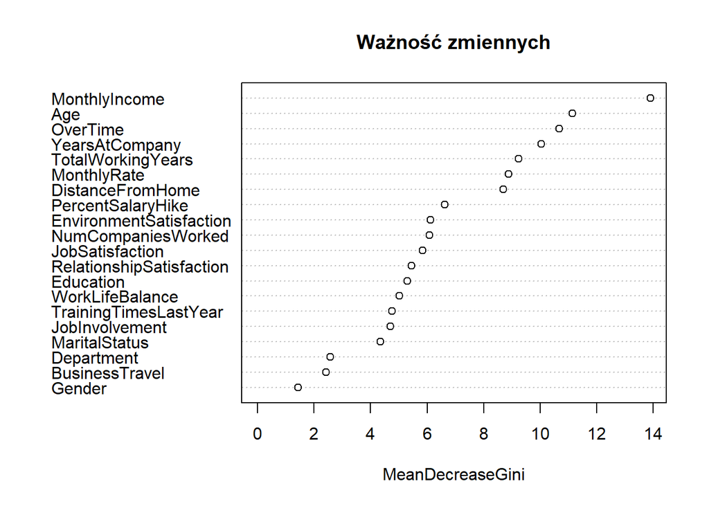

Wartość błędu klasyfikacji dla klasyfikcaji braku wypalenia wynosi 0.0580046, natomiast zarówno dla klasy wypalenia 0.5209581. Błąd klasyfikacji dla wszystkich danych jest na poziomie 13.31%

### Rysunek drzewka

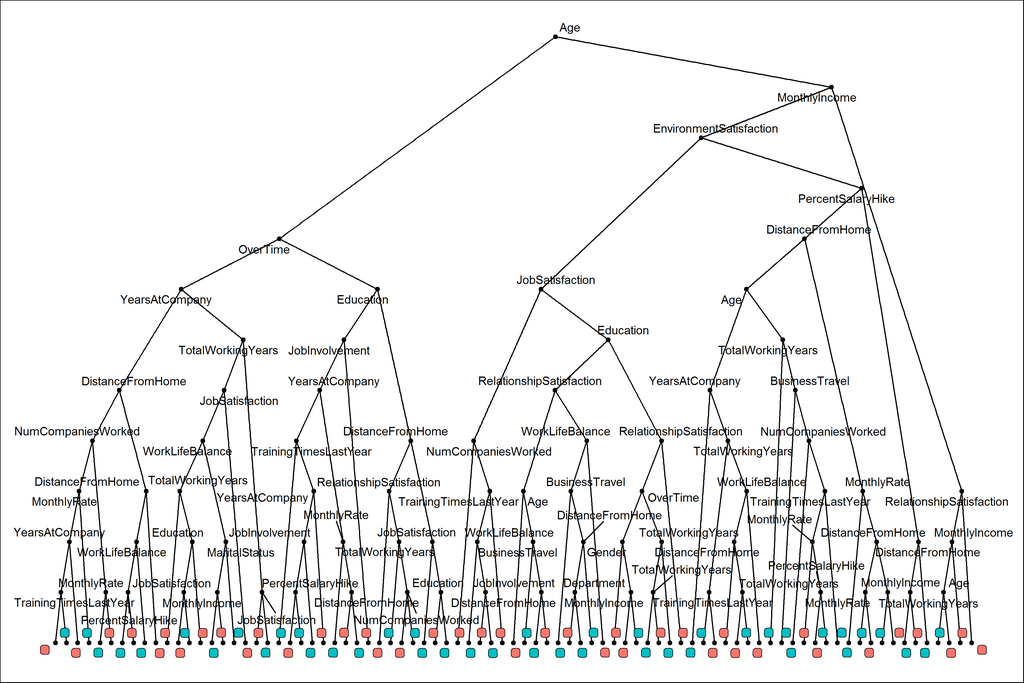

### Predykcja

| Random Forest | Random Forest Obs 0 | Random Forest Obs 1 |
| --- | --- | --- |
| Pred |  |  |
| 0 | 353 | 38 |
| 1 | 18 | 32 |

celność: 87%

## GBM

GBM (ang. *Gradient Boosting Machines*) jest wysokowydajnym, wspomaganym gradientem ramowym algorytmem drzewa decyzyjnego, używanym do tworzenia rankingu, klasyfikacji i wielu innych zadań uczenia maszynowego.

Polega na iteracyjnym poprawianiu modelu analizując reszty (błędy klasyfikacyjne) - każdy nastepny model budowany jest w taki sposób, aby przewidywał lepiej te przypadki, w których model poprzedni nie dawał sobie rady wystarczająco dobrze.

### Model

Model zbudowany został za pomocą funkcji `train()` z argumentem *method = “gbm”* z pakietu `caret`, która liczbę drzew (`n.trees`), liczbę podziałów w drzewach (`interaction.depth`) i parametr kurczenia (`shrinkage`) ustala automatycznie, za kryterium przyjmując największą celność przewidywania (`Accuracy`).

Do modelu włączone zostaną wszystkie zmienne numeryczne ze zbioru oraz te cechy kategoryczne, które wykazują związek z `Attrition`.

```
Stochastic Gradient Boosting

980 samples
 16 predictor
  2 classes: 'No', 'Yes'

No pre-processing
Resampling: Bootstrapped (25 reps)
Summary of sample sizes: 980, 980, 980, 980, 980, 980, ...
Resampling results across tuning parameters:

  interaction.depth  n.trees  Accuracy   Kappa
  1                   50      0.8490523  0.1542553
  1                  100      0.8530390  0.2270727
  1                  150      0.8531081  0.2570003
  2                   50      0.8538072  0.2430418
  2                  100      0.8541697  0.2783130
  2                  150      0.8535278  0.2963683
  3                   50      0.8535883  0.2586688
  3                  100      0.8514129  0.2804716
  3                  150      0.8509619  0.2941394

Tuning parameter 'shrinkage' was held constant at a value of 0.1

Tuning parameter 'n.minobsinnode' was held constant at a value of 10
Accuracy was used to select the optimal model using the largest value.
The final values used for the model were n.trees = 100, interaction.depth =
 2, shrinkage = 0.1 and n.minobsinnode = 10.
```

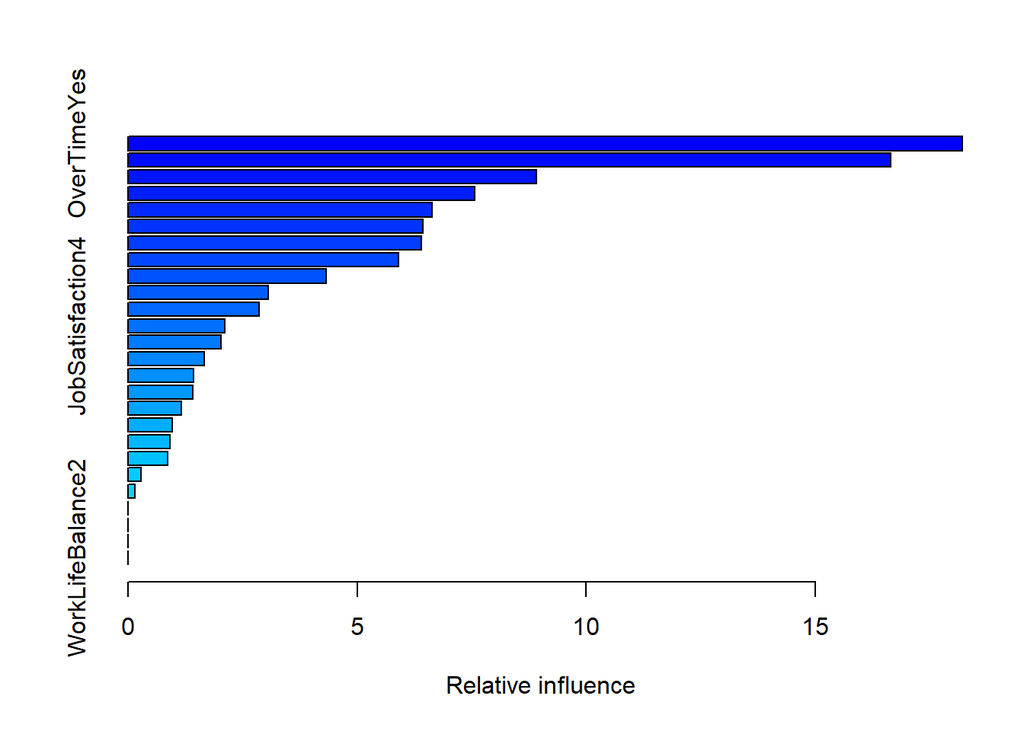

| var | rel.inf |
| --- | --- |
| OverTimeYes | 18.2078783 |
| MonthlyIncome | 16.6497116 |
| YearsAtCompany | 8.9144155 |
| TotalWorkingYears | 7.5707167 |
| DistanceFromHome | 6.6413869 |
| Age | 6.4422866 |
| NumCompaniesWorked | 6.4011783 |
| MaritalStatusSingle | 5.9034289 |
| MonthlyRate | 4.3296242 |
| PercentSalaryHike | 3.0679046 |
| WorkLifeBalance3 | 2.8571801 |
| JobSatisfaction4 | 2.1182247 |
| TrainingTimesLastYear | 2.0258199 |
| EnvironmentSatisfaction3 | 1.6709734 |
| DepartmentResearch & Development | 1.4398019 |
| EnvironmentSatisfaction4 | 1.4103074 |
| DepartmentSales | 1.1583691 |
| JobInvolvement4 | 0.9706663 |
| JobSatisfaction2 | 0.9227365 |
| JobInvolvement3 | 0.8674679 |
| EnvironmentSatisfaction2 | 0.2839399 |
| WorkLifeBalance4 | 0.1459813 |
| JobInvolvement2 | 0.0000000 |
| JobSatisfaction3 | 0.0000000 |
| MaritalStatusMarried | 0.0000000 |
| WorkLifeBalance2 | 0.0000000 |

### Predykcja

| GBM | GBM Obs No | GBM Obs Yes |
| --- | --- | --- |
| Pred |  |  |
| No | 399 | 58 |
| Yes | 12 | 21 |

celność: 86%

## Regresja logistyczna

Regresja logistyczna (ang. *logistic regression*) jest techniką klasyfikacyjną stosowaną wtedy i tylko wtedy gdy zmienna objaśniana przyjmuje dwa stany (sukces i porażka). Polega ona na modelowaniu warunkowego prawdopodobieństwa sukcesu za pomocą kombinacji liniowej predyktorów **X**, które mogą również pochodzić ze skali jakościowej.

### Model

Jako sukces przyjmujęmy wystąpienie poziomu `Yes` dla zmiennej `Attrition`.

|  | Model 1 |
| --- | --- |
| (Intercept) | 1.91 |
|  | (1.09) |
| Age | -0.02 |
|  | (0.02) |
| DistanceFromHome | 0.05 *** |
|  | (0.01) |
| MonthlyIncome | -0.00 * |
|  | (0.00) |
| MonthlyRate | 0.00 |
|  | (0.00) |
| NumCompaniesWorked | 0.18 *** |
|  | (0.05) |
| PercentSalaryHike | -0.00 |
|  | (0.03) |
| TotalWorkingYears | -0.06 |
|  | (0.03) |
| TrainingTimesLastYear | -0.09 |
|  | (0.08) |
| YearsAtCompany | 0.01 |
|  | (0.03) |
| DepartmentResearch & Development | -0.45 |
|  | (0.54) |
| DepartmentSales | 0.29 |
|  | (0.55) |
| EnvironmentSatisfaction2 | -0.94 ** |
|  | (0.31) |
| EnvironmentSatisfaction3 | -1.29 *** |
|  | (0.30) |
| EnvironmentSatisfaction4 | -1.18 *** |
|  | (0.29) |
| JobInvolvement2 | -1.16 ** |
|  | (0.42) |
| JobInvolvement3 | -1.55 *** |
|  | (0.40) |
| JobInvolvement4 | -2.37 *** |
|  | (0.56) |
| JobSatisfaction2 | -0.50 |
|  | (0.32) |
| JobSatisfaction3 | -0.50 |
|  | (0.28) |
| JobSatisfaction4 | -1.07 *** |
|  | (0.29) |
| MaritalStatusMarried | 0.25 |
|  | (0.30) |
| MaritalStatusSingle | 1.11 *** |
|  | (0.29) |
| OverTimeYes | 1.87 *** |
|  | (0.22) |
| WorkLifeBalance2 | -0.79 |
|  | (0.43) |
| WorkLifeBalance3 | -1.27 ** |
|  | (0.41) |
| WorkLifeBalance4 | -0.94 |
|  | (0.49) |
| N | 980 |
| AIC | 692.60 |
| BIC | 824.56 |
| Pseudo R2 | 0.35 |
| *** p < 0.001; ** p < 0.01; * p < 0.05. |  |

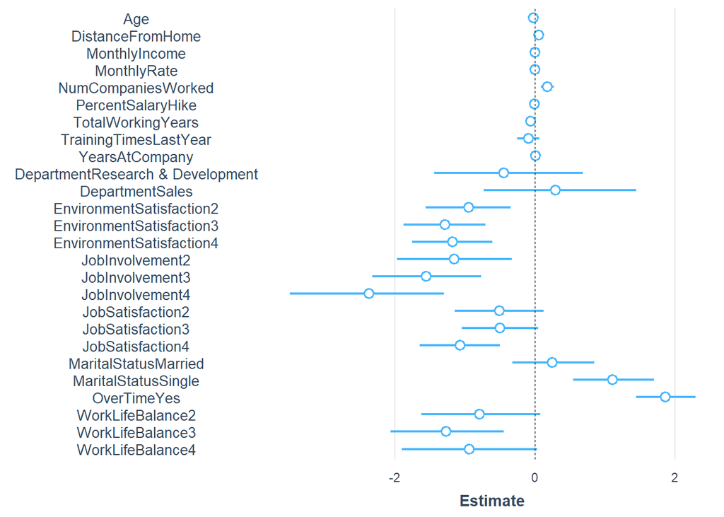

Z powyższego zestawienia widzimy, że czynniki stymulujące (zwiększające prawdopodobieństwo wystąpienia wypalenia zawodowego) to *DistanceFromHome, MonthlyRate, NumCompaniesWorked, YearsAtCompany, DepartmentSales, MaritalStatusMarried, MaritalStatusSingle, OverTimeYes*.

### Predykcja

| Logit | Logit Obs No | Logit Obs Yes |
| --- | --- | --- |
| Pred |  |  |
| No | 394 | 56 |
| Yes | 17 | 23 |

celność: 85%

## Porównanie

| LDA | LDA Obs No | LDA Obs Yes |
| --- | --- | --- |
| Pred |  |  |
| No | 384 | 57 |
| Yes | 27 | 22 |

celność: 83%

| KNN | KNN Obs No | KNN Obs Yes |
| --- | --- | --- |
| Pred |  |  |
| No | 405 | 75 |
| Yes | 6 | 4 |

celność: 83%

| Random Forest | Random Forest Obs 0 | Random Forest Obs 1 |
| --- | --- | --- |
| Pred |  |  |
| 0 | 353 | 38 |
| 1 | 18 | 32 |

celność: 87%

| GBM | GBM Obs No | GBM Obs Yes |
| --- | --- | --- |
| Pred |  |  |
| No | 399 | 58 |
| Yes | 12 | 21 |

celność: 86%

| Logit | Logit Obs No | Logit Obs Yes |
| --- | --- | --- |
| Pred |  |  |
| No | 394 | 56 |
| Yes | 17 | 23 |

celność: 85%